# Banco Federal de Finanças Report

- Show All Code
- Hide All Code

Target Marketing Campaign

Author

Team 4

## Background

*A major telemarketing campaign and the results were inadequete to come to a conclusion. We were assigned to impelment a Machine Learning Algorithim to help find the following:*

*1. Find interesting customer segments based on their previous marketing campaign.* *2. Find a way to identify the types of customers most likely to respond favorably to future marketing campaigns.* *3.Proving to a skeptical Senhor Ferreira that a targeted campaign based on data science will significantly outperform a campaign made up of randomly selected customers.*

*Since we’re operating in the European Union, we’re subject to GDPR compliance requirements. The GDPR doesn’t apply in this situation, since we’re just building a model, not selling data. In order to use this data under GDPR, we’ll need to get consent from the customers in the dataset. We are also using only historic data that has been put into an anonymous format so we will be compliant in that department as well.*

## Methodology

*We decided that using a supervised approach would be ideal for this job because we are trying to classify our clientele would have interest in subscribing to a term deposit. Supervised approaches are better for getting a finite answer. When we took our data we decided that use eighty percent of the data for training and the remaining data for testing and validation. We chose this distribution due to this being a relatively small dataset and is the standard distribution for supervised learning models.*

*Before we even started applying the data to our learning model. We needed to adjust some of our data to make it more usable. We changed how recently people had been contacted to move the people who had not been contacted into separate groups. We also made it a point to put our numeric data in groups not using them as individuals.*

## Tree

*For our model, we decided to use the RandomForestClassifier which constructs multiple decision trees during the training phase and then combines their predictions to produce more accurate and stable results. We augmented the RandomForestClassifier using hyperparameters which controlled certain aspects of the final decision tree, including the number of trees in the forest, the max depth of each tree, and the number of samples required to split an internal node. The hyperparameters are determined by using GridSearchCV, which will search over a specified parameter grid, and determine the best parameters by which we should control the decision tree.*

## Metrics

We decided the most important metric is recall. We wanted to make sure we get as many yes’s with the least amount of calls. Then precesion is the next important. The data we validated our model with included 3,707 pepole. Of those people we predicted that 3,456 would say no and 251 would say yes. We had a 28.7% recall and a 52.2% precision. This means that our model only got around 30% of the people that said yes. But over half of the people the model said was a yes, would actually agree to the campaign. This means that every other person you call will agree to the campaign. So we weren’t able to get all the people that would say yes, but we cut out over 3,100 calls out. So you would be able to save a lot of time and money cutting out all the other calls you would have been making.

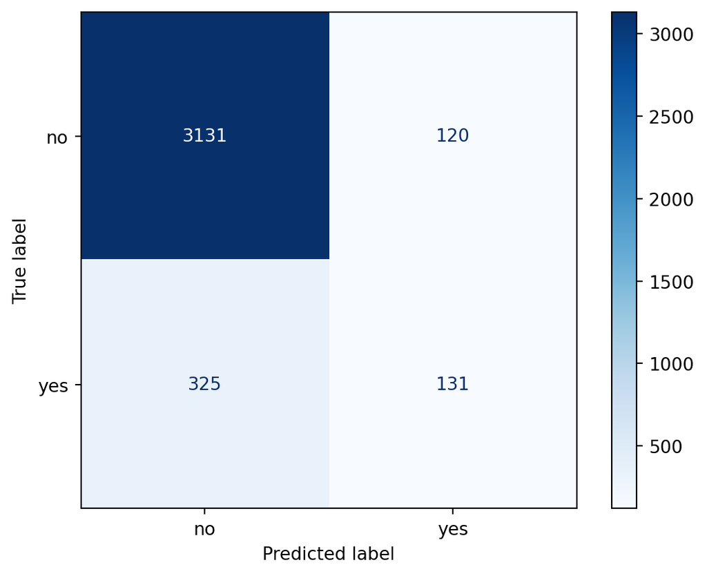

```python
disp = ConfusionMatrixDisplay.from_estimator(
  clf,
  X_test,
  y_test,
  cmap=plt.cm.Blues,)
plt.show()
```

## Questions

```python
#chart3
```

[output not shown]

```python
#chart2
```

[output not shown]

```python
#chart1
```

[output not shown]